# Long Memory ARIMA

- Show All Code
- Hide All Code
- View Source

Author

Pritom Roy

## Long Memory ARMA

The ARMA process can be written as a linear process $x_t=\sum\limits_{j=0}^\infty \psi_j w_{t-j}$ and it can be shown that coefficients in the representation dominated by exponential decay. For example the ARMA(1,1) under the linear representations becomes

$$\begin{align*}
&x_t = \phi x_{t-1}+w_t+\theta w_{t-1}\\
\implies &x_t - \phi x_{t-1} = w_t+\theta w_{t-1}\\
\implies &(1 - \phi B)x_{t} = (1+\theta B)w_{t}\\
\implies &x_{t} = (1+\theta B) \frac{1}{1 - \phi B}w_{t}\\
&\quad = (1+\theta B) \sum_{i=0}^\infty (\phi B)^i w_{t}\\
&\quad = \left[\sum_{i=0}^\infty (\phi B)^i + \sum_{i=0}^\infty (\phi B)^i (\theta B)\right] w_{t}\\
&\quad = [1 + (\phi B) + (\phi B)^2 + (\phi B)^3 + (\phi B)^4 + \dots\\
&\qquad~\qquad (\theta B) + (\theta B)(\phi B) + (\theta B)(\phi B)^2 + (\theta B)(\phi B)^3+\dots]\\
&\quad = [1 + (\phi B) + (\phi B)^2 + (\phi B)^3 + (\phi B)^4 + \dots\\
&\qquad~\qquad (\theta B) + (\theta )(\phi B^2) + (\theta )(\phi^2B^3) + (\theta )(\phi^3 B^4)+\dots]\\
&= [1 + (\phi+\theta )B + (\phi^2 + (\theta )\phi )B^2 + (\phi ^2+(\theta )\phi ^2)B^3 +\\
&~\quad (\phi^4+(\theta )\phi^3)B^4 + \dots]w_t\\
&= [1 + (\phi + \theta )B + \phi(\phi + \theta )B^2 + \phi^2(\phi + \theta )B^3 + \phi^3(\phi + \theta )B^4 + \dots]w_t\\
&= w_t + (\phi + \theta )w_{t-1} + \phi(\phi + \theta )w_{t-2} + \phi^2(\phi + \theta )w_{t-3} + \phi ^3(\phi + \theta )w_{t-4} + \dots\\
\end{align*}$$

So here we can see the effect of the past is quickly fading as there is exponential terms. This result implies the ACF of the short memory process satisfies $\rho(h)\to0$ exponentially fast as $h \to\infty$. When the sample ACF of a time series decays slowly the advice given to difference the series until it seems stationary.

This process has a drawback which is we can only choose the discrete difference values as {0,1,2,…} which may sometime leads to under or over differencing of the original process. The long memory ARMA is intermediate compromises between $\text{ARIMA}(p,d = 0,q)$ and $\text{ARIMA}(p,d = 1,q)$ models.

## ARFIMA(0,d,0) Model

$$\begin{align*}
&\Phi(B)(1-B)^bx_t = \Theta(B)w_t\qquad |b|\in [0,.5)\quad \Phi(B)=\Theta(B)=1\\
\implies&(1-B)^bx_t = w_t\\
\implies&x_t= (1-B)^{-b}w_t\\
&\quad= \sum_{j = 0}^\infty \frac{\Gamma(j+d)}{\Gamma(j+1)\Gamma(d)} w_{t-j}\\
&\quad= \sum_{j = 0}^\infty \psi_j w_{t-j}\\
Cov(x_t,x_{t+h}) &= Cov\left(\sum_{j=0}^\infty \psi_jw_{t-j}, \sum_{k=0}^\infty \psi_kw_{t+h-k}\right)\\
&= Cov\left(\sum_{j=0}^\infty \psi_jw_{t-j}, \sum_{j+h=0}^\infty \psi_{j+h}w_{t+h-(j+h)}\right) \quad [t-j=t+h-k\implies k=j+h]\\
&= Cov\left(\sum_{j=0}^\infty \psi_j w_{t-j}, \sum_{j=-h}^\infty \psi_{j+h}w_{t-j}\right)\\
&=\sigma_w^2 \sum_{j=0}^\infty \psi_j \psi_{j+h}\\
&=\sigma_w^2 \sum \frac{\Gamma(j+d)}{\Gamma(j+1)\Gamma(d)}\times \frac{\Gamma(j+h+d)}{\Gamma(j+h+1)\Gamma(d)}\\
\gamma(h)&=\sigma_w^2 \frac{\Gamma(1-2d)}{\Gamma(1-d)^2}\frac{\Gamma(h+d)}{\Gamma(h+1-d)}\\
\gamma(0)&=\sigma_w^2 \frac{\Gamma(1-2d)}{\Gamma(1-d)^2}\frac{\Gamma(d)}{\Gamma(1-d)}\\
\rho(h)&=\frac{\gamma(h)}{\gamma(0)}= \frac{\Gamma(h+d)\Gamma(1-d)}{\Gamma(h+1-d)\Gamma(d)} \approx h^{2d-1} \quad \text{For large }h\\
&\sum_{h=-\infty}^{+\infty} |h^{2d-1}| = \infty \qquad |h|\in [0,0.5)
\end{align*}$$

## Parameter Estimation ARFIMA(0,d,0)

The parameter estimation process involves minimizing the sum of squares $Q(d)=\sum w_t^2(d)$. Here, one notable thing is that the long memory ARIMA can model data without the help of any other AR or MA parameters. The only parameter $d$ can be used to describe the long memory process.

$$\begin{align*}
w_t(d) &= \sum (1-B)^d x_t\\
&= \sum_{j=0}^{n-1} \frac{\Gamma(j-d)}{\Gamma(j+1)\Gamma(-d)} x_t\\
&= \sum_{j=0}^{n-1} \pi_j(d) x_t\qquad \pi_0(d)=1\\
Q(d)&=\sum w_t^2(d)\\
Q'(d)&= 2\sum_{t=1}^n w_t(d) w_t'(d)\\
Q''(d)&= 2\sum_{t=1}^n [w_t'(d)^2+ w_t(d)w_t''(d)]\approx 2\sum_{t=1}^n w_t'(d)^2\\
d_{(k+1)} &= d_{(k)} - \frac{Q'(d)}{Q''(d)}\\
&= d_{(k)} - \frac{\sum_{t=1}^n w_t(d) w_t'(d)}{\sum_{t=1}^n w_t'(d)^2}\\
\end{align*}$$

## Model fitting

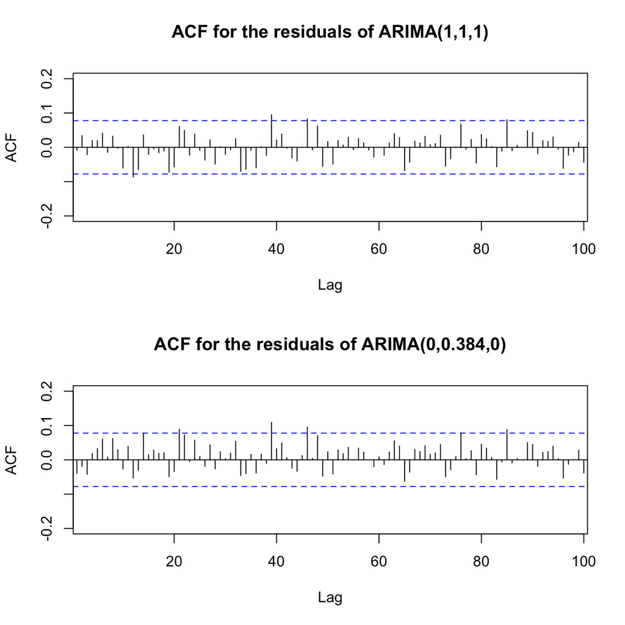

```r
library(fracdiff)
data(varve,package = "astsa")
lvarve = log(varve) - mean(log(varve))
varve.fd = fracdiff(lvarve, nar = 0, nma = 0, M = 30)


res.fd = diffseries(log(varve), varve.fd$d)
res.arima = resid(arima(log(varve), order = c(1, 1, 1)))
par(mfrow = c(2, 1))
acf(res.arima, 100, xlim = c(4, 97), ylim = c(-.2, .2), main = "ACF for the residuals of ARIMA(1,1,1)")
acf(res.fd, 100, xlim = c(4, 97), ylim = c(-.2, .2), main = "ACF for the residuals of ARIMA(0,0.384,0)")
```

## Forcasting

The one step ahead prediction can be obtained by considering converting the ARFIMA model to the linear process. $m$ step ahead prediction can be obtained sequantially.

$$\begin{align*}
&\sum_{j=0}^\infty \pi_j(d) x_{t-j} = w_t\\
\implies& x_{t}+\sum_{j=1}^\infty \pi_j(d) x_{t-j} = w_t\qquad\pi_0(d)=1\\
\implies& x_{t} = w_t-\sum_{j=1}^\infty \pi_j(d) x_{t-j}\\
\implies& \hat{x}_{t} = -\sum_{j=1}^{n-1} \pi_j(\hat{d}) x_{t-j}\\
\implies& \tilde{x}_{n+m}^n = -\sum_{j=1}^{n} \pi_j(\hat{d}) \tilde{x}_{n+m-j}^n\\
\end{align*}$$

## ARFIMA(p,d,q) Model

The full model can be written as
$$\phi(B)\nabla^d(x_t-\mu)=\theta(B)w_t$$

Where $|d|\in [0,.5)$ and the positive values indicate persistancy and the negative values indicates lack of persistance. For estimating the parameter we need the equation
$$w_t=\sum_{j=0}^\infty \pi_j(x_{t-j}-\mu)$$

And for forcasting we are going to need the equation
$$x_t=\mu+\sum_{j=0}^\infty \psi_jw_{t-j}$$

## Frequency Domain Approach

The frequency $\omega$ in the frequency domain approach can be estimated using the equation below where we are skipping the intermediate details steps and derrivations
$$f_x(\omega) = \frac{\sigma_w^2}{|\sum_{k=0}^\infty \pi_ke^{-2\pi ik\omega}|^2}=[4sin^2(\pi\omega)]^{-d}\sigma_w^2$$

## Parameter Estimation (Frequency Domain Approach)

The likelihood based method is used to estinate the parameter value form the spectram analysis
$$\begin{align*}
f_x(\omega_k; d, \sigma_w^2) &= \sigma_w^2\, g_k^{-d};\qquad g_k = 4 \sin^2(\pi \omega_k)\\
\ln L(x; d, \sigma_w^2)&\approx -m \ln \sigma_w^2 + d \sum_{k=1}^{m} \ln g_k-\frac{1}{\sigma_w^2} \sum_{k=1}^{m} g_k^{\,d} I(\omega_k)\qquad m=n/2-1\\
\hat{\sigma}_w^2(d)&= \frac{1}{m} \sum_{k=1}^{m} g_k^{\,d} I(\omega_k)\\
\end{align*}$$

```r
series = log(varve) # specify series to be analyzed
d0 <-  .1 # initial value of d

n.per = nextn(length(series))
m = (n.per)/2 - 1
per = Mod(fft(series-mean(series))[-1])^2 # remove 0 freq and
per = per/n.per # scale the peridogram
g = 4*(sin(pi*((1:m)/n.per))^2)
# Function to calculate -log.likelihood
whit.like = function(d){
  g.d <- g^d
  sig2 <- (sum(g.d*per[1:m])/m)
  log.like <- m*log(sig2) - d*sum(log(g)) + m
  return(log.like)
  }

est = optim(d0, whit.like, gr=NULL, method="L-BFGS-B", hessian=TRUE,lower=-.5, upper=.5, control=list(trace=1,REPORT=1))
```

```r
cat("d.hat =", est$par,"se(dhat) =",1/sqrt(est$hessian),"\n")
```

```
d.hat = 0.3802707 se(dhat) = 0.02848478
```

```r
cat("d.hat =", varve.fd$d,"se(dhat) =",varve.fd$stderror.dpq,"\n")
```

```
d.hat = 0.3841688 se(dhat) = 4.589514e-06
```